# STATS 503 HW 2

## Shuo Qin

### Question 1

#### (a)

1. (0-0)^2 + (0-3)^2 + (0-0)^2 = 9
2. (0-2)^2 + (0-0)^2 + (0-0)^2 = 4
3. (0-0)^2 + (0-1)^2 + (0-3)^2 = 10
4. (0-0)^2 + (0-1)^2 + (0-2)^2 = 5
5. (0+1)^2 + (0-0)^2 + (0-1)^2 = 2
6. (0-1)^2 + (0-1)^2 + (0-2)^2 = 6

So the 6 squared distances are 9, 4, 10, 5, 2, 6.

#### (b)

Based on the squared euclidean distance, we can tell that squared distance 2, 4, 5 are the three(because K = 3) closest to the test point. This corresponding to red, green, and green. Thus the result it green because the amount of green is greater than red in this case.

#### (c)

Based on the squared euclidean distance, we can tell that squared distance 2 is the three(because K = 1) closest to the test point. This corresponding to green. Thus the result it green.

#### (d)

True. Because I think when K is small, it has a higher variance and a low bias. When K = 1, the algorithm will look for that one point closest to the test point and so it is very sensitive to the specific of training data. As we increase the K, it will have more options which lower the variance. In this case, when K is bigger, the probability should be bigger as well.

### Question 2

### (a)

True.

### (b)

This relationship can be express through a U-shape graph on the x,y axis where the x-axis is model complexity and the y-axis is error. When flexibility increase, the test error should decrease. In the middle point of this U-shape graph, we have the optimum model complexity point where the bias and variance are very balance and the test error has its lowest point. After this point, the error on testing data starts to increase because it is "overfitting".

### Question 3

```python
import numpy as np
import pandas as pd
from sklearn.linear_model import LinearRegression
import matplotlib.pyplot as plt
import math
```

### (a)

```python
x = 0.5
a = x + np.cos(2 * np.pi * x) - 0.1
b = x + np.cos(2 * np.pi * x) + 0.1
f = (a+b)/2
print("f(0.5) is " + str(f))
```

```
f(0.5) is -0.5
```

### (b)

```python
x = 0.5
a = x + np.cos(2 * np.pi * x) - 0.1
b = x + np.cos(2 * np.pi * x) + 0.1
var_f = ((b-a)**2)/12
print("var(Y|X = 0.5) is " + str(var_f))
```

```
var(Y|X = 0.5) is 0.003333333333333332
```

### (c)

[figure not shown]

```
f_hat(0.5; D) is [0.56325624]
```

```python
np.random.seed(123)

X = np.random.uniform(0, 1, 100)
Y = np.random.uniform(X + np.cos(2 * np.pi * X) - 0.1, X + np.cos(2 * np.pi * X) + 0.1, 100)

dataset_D = pd.DataFrame({
    'X': X,
    'Y': Y
})

X_reshaped = data['X'].values.reshape(-1, 1)

model = LinearRegression()
model.fit(X_reshaped, data['Y'])

data['Y_pred'] = model.predict(X_reshaped)

## Plot

plt.scatter(data['X'], data['Y'], color='blue', label='Dataset')
plt.plot(data['X'], data['Y_pred'], color='red', label='Linear Fit')
plt.axvline(x=0, color='green', linestyle='--', label='X=0')

## True regression
X = np.linspace(0, 1, 100)
true_Y = np.square(X)
plt.plot(X, true_Y, color='green', label='True Regression Function')

def f_filled(x):
    return np.square(x) + 1
def g_filled(x):
    return np.square(x) - 1


plt.grid(True)
plt.xlabel('X')
plt.ylabel('Y')
plt.title('Linear Regression')
plt.legend()
plt.show()


f_hat = model.predict([[0.5]])
print("f_hat(0.5; D) is " + str(f_hat))
```

### (d)

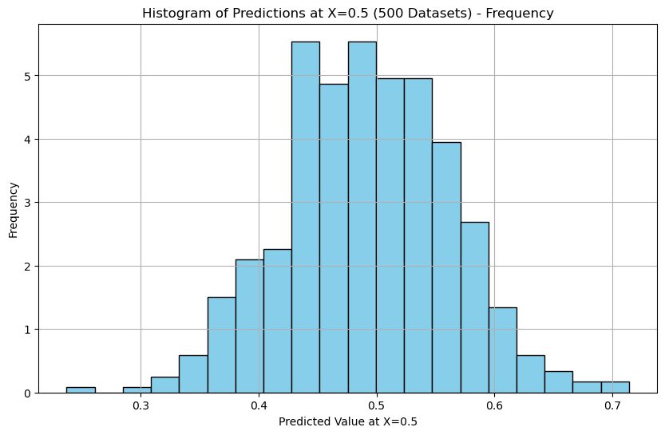

```python
n_datasets = 500
predictions_x_0 = np.zeros(n_datasets)
x_0 = 0.5

for i in range(n_datasets):

    X = np.random.uniform(0, 1, 100)
    Y = np.random.uniform(X + np.cos(2 * np.pi * X) - 0.1, X + np.cos(2 * np.pi * X) + 0.1, 100)

    data = pd.DataFrame({
        'X': X,
        'Y': Y
    })

    X_reshaped = data['X'].values.reshape(-1, 1)
    model = LinearRegression()
    model.fit(X_reshaped, data['Y'])

    data[f'Y_pred_{i}'] = model.predict(X_reshaped)
    y_pred = model.predict([[x_0]])
    predictions_x_0[i] = y_pred

# Plotting the histogram of predictions
plt.figure(figsize=(10, 6))
plt.hist(predictions_x_0, bins=20, color='skyblue', edgecolor='black',  density=True)
plt.xlabel('Predicted Value at X=0.5')
plt.ylabel('Frequency')
plt.title('Histogram of Predictions at X=0.5 (500 Datasets) - Frequency')
plt.grid(True)
plt.show()
```

### (e)

```python
average_prediction = np.mean(predictions_x_0)
print(f"The average prediction at x_0=0.5 is: {average_prediction}")
```

```
The average prediction at x_0=0.5 is: 0.4959385935893432
```

### (f)

```python
variance = np.var(predictions_x_0)
print(f"The variance at x_0=0.5 is: {variance}")
```

```
The variance at x_0=0.5 is: 0.005538776431174515
```

Based on the result, it seems like the variance of the ordinary least squares estimator ˆf (0.5, D) is pretty low which also indicates that the model's predication is relatively consistent which is a good thing.

### (g)

From the formula, we know that $$ \mathrm{E[(y_0 - \hat{f}(x_0))^2]} = [\mathrm{Bias(\hat{f}(x_0))^2}] + \mathrm{Var(\hat{f}(x_0))} + \mathrm{Var}(\epsilon) $$

```python
# True value at X=0
true_value = x_0**2

n_datasets = 100
predictions_x_0 = np.zeros(n_datasets)
x_0 = 0.5

for i in range(n_datasets):

    X = np.random.uniform(0, 1, 100)
    Y = np.random.uniform(X + np.cos(2 * np.pi * X) - 0.1, X + np.cos(2 * np.pi * X) + 0.1, 100)

    data = pd.DataFrame({
        'X': X,
        'Y': Y
    })

    X_reshaped = data['X'].values.reshape(-1, 1)
    model = LinearRegression()
    model.fit(X_reshaped, data['Y'])

    data[f'Y_pred_{i}'] = model.predict(X_reshaped)
    y_pred = model.predict([[x_0]])
    predictions_x_0[i] = y_pred


# Calculate bias and variance
average_prediction = np.mean(predictions_x_0)
bias = np.mean(average_prediction - true_value)
variance = np.var(predictions_x_0)
irreducible_error = 1

expected_squared_error = np.mean(bias**2 + variance + irreducible_error)
print(expected_squared_error)
```

```
1.063932326997227
```

### Question 4

Around 5~6 hours.